# Analysing the COMPADRE database using R

Mario Vallejo-Marin

March 15 2017

# The COMPADRE database

Is a compilation of plant population matrices. See www.compadre-db.org. Currently it has 7,024 population matrices for thousands of species.

## Downloading and reading the data in `R`

You can download the data from the website. The database is in `R` format. Save it to your computer, within the working environment of R, so you can then load it and analyse it.

```r
load(file="COMPADRE_v.4.0.1.RData")
```

This will result in a database object called `compadre`. It is a big file of about 45Mb.

The dataframe is arranged in a series of nested levels. At the highest level it has the following components:

```r
summary(compadre)
```

```
##             Length Class      Mode
## metadata      47   data.frame list
## matrixClass 7024   -none-     list
## mat         7024   -none-     list
## version        6   -none-     list
```

The `metadata` section contains 47 variables. For a detailed description of the meaning of each of them see the user manual, which is available [here](https://github.com/jonesor/compadreDB/tree/master/COMPADRE-UserGuide).

Accessing the elements of `compadre` can be done using the operator `$`, just as you would do to access the columns of a simple data base.

```r
names(compadre$metadata)
```

```
##  [1] "SpeciesAuthor"          "SpeciesAccepted"
##  [3] "CommonName"             "Genus"
##  [5] "Family"                 "Order"
##  [7] "Class"                  "Phylum"
##  [9] "Kingdom"                "OrganismType"
## [11] "DicotMonoc"             "AngioGymno"
## [13] "Authors"                "Journal"
## [15] "YearPublication"        "DOI.ISBN"
## [17] "AdditionalSource"       "StudyDuration"
## [19] "StudyStart"             "StudyEnd"
## [21] "AnnualPeriodicity"      "NumberPopulations"
## [23] "MatrixCriteriaSize"     "MatrixCriteriaOntogeny"
## [25] "MatrixCriteriaAge"      "MatrixPopulation"
## [27] "Lat"                    "Lon"
## [29] "Altitude"               "Country"
## [31] "Continent"              "Ecoregion"
## [33] "StudiedSex"             "MatrixComposite"
## [35] "MatrixTreatment"        "MatrixCaptivity"
## [37] "MatrixStartYear"        "MatrixStartSeason"
## [39] "MatrixStartMonth"       "MatrixEndYear"
## [41] "MatrixEndSeason"        "MatrixEndMonth"
## [43] "MatrixSplit"            "MatrixFec"
## [45] "Observation"            "MatrixDimension"
## [47] "SurvivalIssue"
```

With a bit of tweaking you can interrogate the database to obtain specific information. For example, to find ou how many genera are included in the data base you can do:

```r
length(levels(as.factor(compadre$metadata$Genus)))
```

```
## [1] 444
```

And you can print the first ten genera in this list:

```r
levels(as.factor(compadre$metadata$Genus))[1:10]
```

```
##  [1] "Abies"        "Abutilon"     "Acacia"       "Acer"
##  [5] "Achillea"     "Aconitum"     "Actaea"       "Actinostemon"
##  [9] "Adenocarpus"  "Adenophora"
```

## Data analysis

You can analyse subsets of the data using this general approach:

```r
#Subset the dataframe by Genus
mimulus.data<-subset(compadre$metadata, Genus=="Mimulus")
#Row numbers for the data containing Mimulus
keep<-as.numeric(rownames(mimulus.data))
#Subsets the matrices using the "keep" list
mat.mimulus<-compadre$mat[keep]
#This is a list of 36 matrices, which can be accessed using indices
mat.mimulus[[1]]
```

```
## $matA
##                A1           A2           A3           A4
## [1,] 1.972500e-01 938.25000000 9069.0833333 1.322798e+05
## [2,] 3.978583e-05   0.06633333    0.0244500 6.333333e-04
## [3,] 2.722000e-05   0.08722500    0.3366333 2.182167e-01
## [4,] 3.719167e-07   0.01748333    0.1384917 5.829917e-01
##
## $matU
##                U1         U2        U3           U4
## [1,] 1.972500e-01 0.00000000 0.0000000 0.0000000000
## [2,] 3.978583e-05 0.06633333 0.0244500 0.0006333333
## [3,] 2.722000e-05 0.08722500 0.3366333 0.2182166667
## [4,] 3.719167e-07 0.01748333 0.1384917 0.5829916667
##
## $matF
##      F1     F2       F3       F4
## [1,]  0 938.25 9069.083 132279.8
## [2,]  0   0.00    0.000      0.0
## [3,]  0   0.00    0.000      0.0
## [4,]  0   0.00    0.000      0.0
##
## $matC
##      C1 C2 C3 C4
## [1,]  0  0  0  0
## [2,]  0  0  0  0
## [3,]  0  0  0  0
## [4,]  0  0  0  0
```

```r
#And you can subset them further:
mat.mimulus[[1]]$matC
```

```
##      C1 C2 C3 C4
## [1,]  0  0  0  0
## [2,]  0  0  0  0
## [3,]  0  0  0  0
## [4,]  0  0  0  0
```

```r
sum(mat.mimulus[[1]]$matC)
```

```
## [1] 0
```

Now things more exciting, as we are ready to conduct analyses at a massive scale.

```r
clonal.flag<-numeric()

#Loop to identify which matC entries are >0; i.e., have some measure of clonality
# Excludes indivisible matrices "NA"
n<-length(compadre$metadata$SpeciesAuthor)

for(i in 1:n){
  sum.matC<-sum(compadre$mat[[i]]$matC)
 # print(clonal.flag)
  if(!is.na(sum.matC) & sum.matC > 0) {
    clonal.flag<-c(clonal.flag,i)
    #print(cbind(i, clonal.flag))
    }
}

#List of species with matC > 0
compadre$metadata$SpeciesAccepted[clonal.flag][1:10]
```

```
##  [1] "Murdannia nudiflora"     "Murdannia nudiflora"
##  [3] "Murdannia nudiflora"     "Murdannia nudiflora"
##  [5] "Hylocomium splendens"    "Hylocomium splendens"
##  [7] "Aspasia principissa"     "Heteropsis flexuosa"
##  [9] "Heteropsis macrophylla"  "Heteropsis oblongifolia"
```

```r
length(compadre$metadata$SpeciesAccepted[clonal.flag])
```

```
## [1] 816
```

```r
levels(as.factor(compadre$metadata$SpeciesAccepted[clonal.flag]))[1:10]
```

```
##  [1] "Aechmea magdalenae"         "Aechmea nudicaulis"
##  [3] "Allium tricoccum"           "Anthericum liliago"
##  [5] "Anthericum ramosum"         "Arctophila fulva"
##  [7] "Arnica angustifolia"        "Asarum canadense"
##  [9] "Aspasia principissa"        "Astrocaryum aculeatissimum"
```

For example, to calculate lambda:

```r
#Calculate lambda for all clonal species:
require(popbio)
n<-length(compadre$metadata$SpeciesAccepted[clonal.flag])
lambda.A<-rep(NA,n)

for(i in 1:n){
  tryCatch({  #Avoids error message due to missing values in x
  lambda.A[i]<-lambda(compadre$mat[[i]]$matA)
  }, error=function(e){})
}
sort(round(lambda.A,3))
```

```
##   [1]   0.000   0.000   0.000   0.000   0.000   0.000   0.000   0.000
##   [9]   0.000   0.000   0.000   0.000   0.000   0.000   0.000   0.000
##  [17]   0.000   0.000   0.000   0.000   0.000   0.000   0.000   0.000
##  [25]   0.000   0.000   0.000   0.000   0.000   0.000   0.000   0.010
##  [33]   0.020   0.040   0.042   0.050   0.050   0.050   0.050   0.050
##  [41]   0.055   0.060   0.060   0.060   0.070   0.087   0.088   0.110
##  [49]   0.117   0.211   0.220   0.228   0.230   0.246   0.250   0.266
##  [57]   0.270   0.270   0.276   0.276   0.281   0.294   0.331   0.332
##  [65]   0.351   0.381   0.409   0.410   0.430   0.430   0.430   0.430
##  [73]   0.438   0.443   0.460   0.461   0.462   0.462   0.466   0.471
##  [81]   0.493   0.507   0.510   0.513   0.528   0.537   0.553   0.556
##  [89]   0.565   0.568   0.577   0.600   0.610   0.623   0.625   0.630
##  [97]   0.630   0.630   0.633   0.644   0.674   0.676   0.678   0.680
## [105]   0.687   0.688   0.692   0.694   0.699   0.700   0.708   0.710
## [113]   0.713   0.713   0.714   0.714   0.714   0.714   0.714   0.714
```

[output cut: 87 more lines]

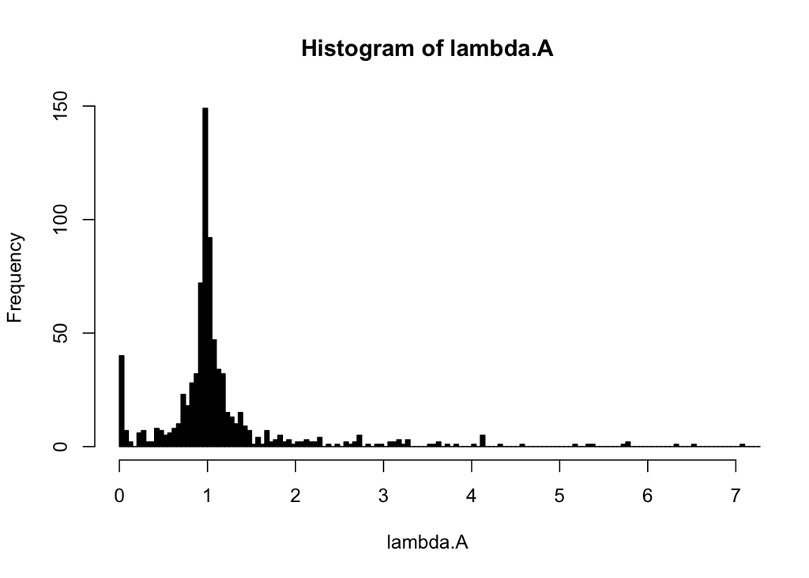

```r
hist(lambda.A, breaks="fd", xlim=c(0,7), col="black") #Omits from the plot all values of lambda>7
```